# Function Friday problems #1

NAME

9/28/2021

## tidytext

```r
library(gutenbergr)
library(tidytext)
library(janeaustenr)
library(dplyr)
```

```r
library(stringr)
library(ggplot2)
```

## 1. Pick a book of your choice

Use `gutenberg_works()` to filter out a book of your choice and replace 768 with `gutenberg_id` to download the text of the book. Below is an example.

```r
books <- gutenberg_works() #assigning gutenberg_works to "books" so we can parse through the list of books
Sherlock <- gutenberg_download(1661, mirror = "http://mirrors.xmission.com/gutenberg/") #downloading The Adventures of Sherlock Holmes, my book of choice
```

## 2. Use unnest_token to clean the data

Use unnest_token to split the line into words.

```r
common_words_sh <- Sherlock %>%
  unnest_tokens(word, text) %>% #using unnest_tokens to turn sentences from each book into a long list of words for analysis.
  count(word, sort = TRUE) #counting the occurrence of each word and sorting them by how often they occur.
head(common_words_sh, 15)
```

```
## # A tibble: 15 × 2
##    word      n
##    <chr> <int>
##  1 the    5623
##  2 and    3018
##  3 i      3003
##  4 to     2744
##  5 of     2655
##  6 a      2640
##  7 in     1766
##  8 that   1744
##  9 it     1701
## 10 you    1481
## 11 he     1467
## 12 was    1410
## 13 his    1159
## 14 is     1124
## 15 my     1007
```

### 3. Filter out the stop words

Filter out the stop words from the previous step.

```r
common_words_sh_sub <- Sherlock %>%
  unnest_tokens(word, text) %>% #using unnest_tokens to turn sentences from each book into a long list of words for analysis
  anti_join(stop_words, by = "word") %>% #using dplyr to get rid of stop words (explain dpyr)
  count(word, sort = TRUE) #counting the occurrence of each word and sorting them by how often they occur.
sh <- head(common_words_sh_sub, 15)
sh
```

```
## # A tibble: 15 × 2
##    word         n
##    <chr>    <int>
##  1 holmes     462
##  2 time       151
##  3 door       144
##  4 matter     125
##  5 hand       120
##  6 house      120
##  7 night      114
##  8 heard      113
##  9 found      108
## 10 day        106
## 11 morning    100
## 12 sherlock    97
## 13 left        92
## 14 miss        88
## 15 eyes        87
```

## 4. Most commonly used words

Find out 15 most frequently used words in the book, after filtering out the stop words.

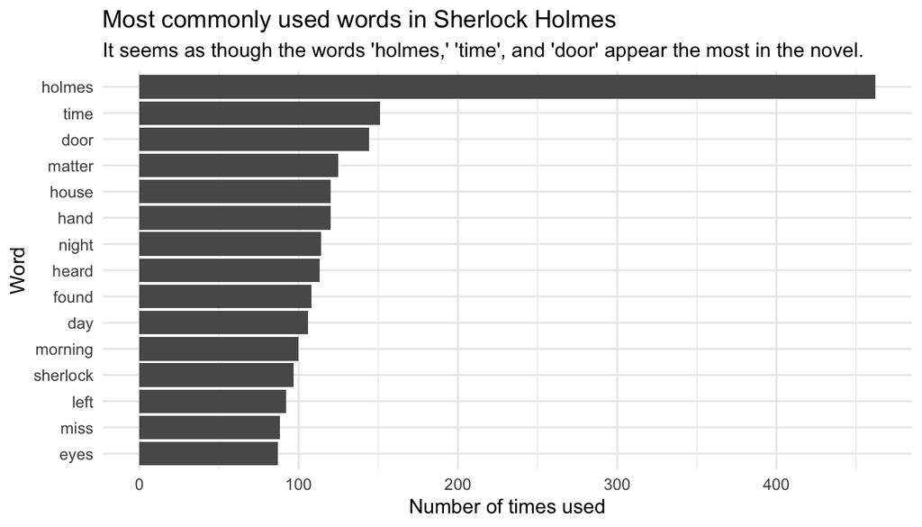

```r
sh %>% #take our list of the top 15 most commonly used words
  ggplot(aes(y = reorder(word,n), x = n)) +
  labs(x = "Number of times used",
       y = "Word",
       title = "Most commonly used words in Sherlock Holmes",
       subtitle = "It seems as though the words 'holmes,' 'time', and 'door' appear the most in the novel.") +
  theme_minimal() +
  geom_col() #create a bar graph
```

The get_sentiments is a function that allows us to get specific sentiment lexicons with appropriate categories for the words. The three general purpose lexicons are AFINN, bing, nrc:

# AFINN - a lexicon measuring sentiment with a numeric score between -5 and +5 # Bing - A binary approach that divides words into either “positive” or “negative” # NRC - categorizes words in a binary fashion (“yes”/“no”) into categories of positive, negative, anger, anticipation, disgust, fear, joy, sadness, surprise, and trust.

## 5. Use get_sentiment to create a visualization of your choice

Play with get_sentiment and create a visualization of your choice. Feel free to use your cleaned book from previous step.

```r
original_books <- austen_books() %>%
  group_by(book) %>%
  mutate(line = row_number(),
         chapter = cumsum(str_detect(text, regex("^chapter [\\divxlc]",
                                                 ignore_case = TRUE)))) %>%
  ungroup()
original_books
```

```
## # A tibble: 73,422 × 4
##    text                    book                 line chapter
##    <chr>                   <fct>               <int>   <int>
##  1 "SENSE AND SENSIBILITY" Sense & Sensibility     1       0
##  2 ""                      Sense & Sensibility     2       0
##  3 "by Jane Austen"        Sense & Sensibility     3       0
##  4 ""                      Sense & Sensibility     4       0
##  5 "(1811)"                Sense & Sensibility     5       0
##  6 ""                      Sense & Sensibility     6       0
##  7 ""                      Sense & Sensibility     7       0
##  8 ""                      Sense & Sensibility     8       0
##  9 ""                      Sense & Sensibility     9       0
## 10 "CHAPTER 1"             Sense & Sensibility    10       1
## # … with 73,412 more rows
```

```r
tidy_books <- original_books %>%
  unnest_tokens(word, text)
# token = 'regex', pattern = "Chapter|CHAPTER [\\dIVXLC]"
tidy_books
```

```
## # A tibble: 725,055 × 4
##    book                 line chapter word
##    <fct>               <int>   <int> <chr>
##  1 Sense & Sensibility     1       0 sense
##  2 Sense & Sensibility     1       0 and
##  3 Sense & Sensibility     1       0 sensibility
##  4 Sense & Sensibility     3       0 by
##  5 Sense & Sensibility     3       0 jane
##  6 Sense & Sensibility     3       0 austen
##  7 Sense & Sensibility     5       0 1811
##  8 Sense & Sensibility    10       1 chapter
##  9 Sense & Sensibility    10       1 1
## 10 Sense & Sensibility    13       1 the
## # … with 725,045 more rows
```

```r
tidy_books %>%
  count(book, word, sort = TRUE) %>%
  anti_join(stop_words) %>%
  bind_tf_idf(word, book, n) %>%
  arrange(desc(tf_idf))
```

```
## # A tibble: 37,224 × 6
##    book                word          n      tf   idf tf_idf
##    <fct>               <chr>     <int>   <dbl> <dbl>  <dbl>
##  1 Sense & Sensibility elinor      623 0.0171   1.79 0.0307
##  2 Sense & Sensibility marianne    492 0.0135   1.79 0.0243
##  3 Emma                emma        786 0.0168   1.10 0.0185
##  4 Mansfield Park      crawford    493 0.0103   1.79 0.0184
##  5 Pride & Prejudice   darcy       373 0.0100   1.79 0.0179
##  6 Persuasion          elliot      254 0.00997  1.79 0.0179
##  7 Emma                weston      389 0.00832  1.79 0.0149
##  8 Northanger Abbey    tilney      196 0.00823  1.79 0.0148
##  9 Pride & Prejudice   bennet      294 0.00789  1.79 0.0141
## 10 Emma                knightley   356 0.00761  1.79 0.0136
## # … with 37,214 more rows
```

```r
positive <- get_sentiments("bing") %>%
  filter(sentiment == "positive") # This filters the entire dataset to look for unigrams (single words) that have positive connotations
positive
```

```
## # A tibble: 2,005 × 2
##    word        sentiment
##    <chr>       <chr>
##  1 abound      positive
##  2 abounds     positive
##  3 abundance   positive
##  4 abundant    positive
##  5 accessable  positive
##  6 accessible  positive
##  7 acclaim     positive
##  8 acclaimed   positive
##  9 acclamation positive
## 10 accolade    positive
## # … with 1,995 more rows
```

```r
cleaned_books <- tidy_books %>%
  anti_join(stop_words %>% filter(lexicon == "SMART"),
            by = 'word')
cleaned_books
```

```
## # A tibble: 244,801 × 4
##    book                 line chapter word
##    <fct>               <int>   <int> <chr>
##  1 Sense & Sensibility     1       0 sense
##  2 Sense & Sensibility     1       0 sensibility
##  3 Sense & Sensibility     3       0 jane
##  4 Sense & Sensibility     3       0 austen
##  5 Sense & Sensibility     5       0 1811
##  6 Sense & Sensibility    10       1 chapter
##  7 Sense & Sensibility    10       1 1
##  8 Sense & Sensibility    13       1 family
##  9 Sense & Sensibility    13       1 dashwood
## 10 Sense & Sensibility    13       1 long
## # … with 244,791 more rows
```

# Example

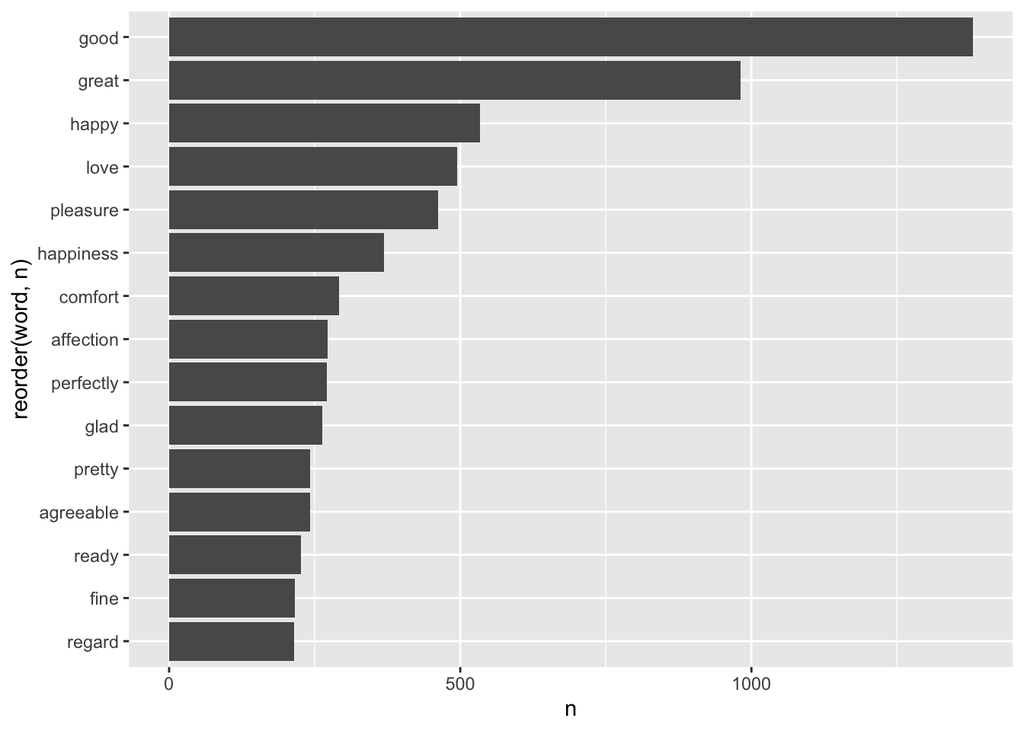

```r
cleaned_books %>%
  semi_join(positive, by = "word") %>%
  count(word, sort = TRUE) %>%
  slice(0:15) %>%
  ggplot(aes(x = n , y = reorder(word,n))) +
  geom_col()
```

# My plot

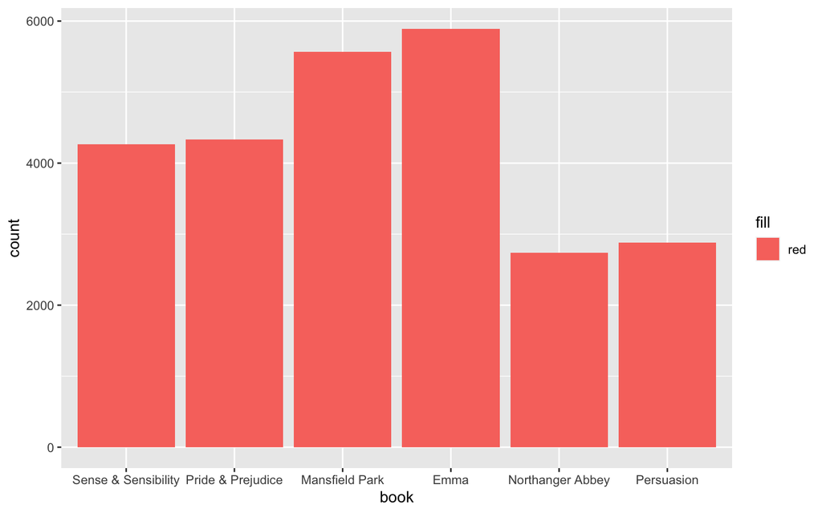

```r
cleaned_books %>%
  semi_join(positive, by = "word") %>%
  group_by(word == "positive") %>%
  ggplot(aes(x = book, fill= 'red') ) +
  geom_bar()
```

# rayshader

If you have trouble installing `rayshader` or get an error when you try to load it, you likely need to install [XQuarts](https://www.xquartz.org/)

```r
library(readxl)
library(sp)
library(png)
library(grid)
library(rayshader)
library(rgl)
```

You will need too download the three datasets from the [GitHub repo](https://github.com/ducminhngo871/ExploringRayShader) (click on the dataset and then click View raw and it should automatically download). Make sure to save the data either to the project folder for this assignment (preferred) or to the same folder where you have saved this Rmd file.

```r
## Here is the 3 datasets
district_name = read_excel('~/Desktop/Fall21/Advanced Data Science/ADS_Assignment/District Name.xlsx',1)
population = read_excel('~/Desktop/Fall21/Advanced Data Science/ADS_Assignment/Population Data.xlsx',1)
colnames(population) = c("Chi_name", "Population")
hkmap = readRDS("~/Desktop/Fall21/Advanced Data Science/ADS_Assignment/HKG_adm1.rds")
```

```r
# The preprocessing part
map_data = data.frame(id=hkmap$ID_1, Code=hkmap$HASC_1, Eng_name=hkmap$NAME_1)
map_data$Code = gsub('HK.', '', as.character(map_data$Code))
map_data = merge(map_data, district_name, by = 'Eng_name')
hkmapdf = fortify(hkmap)
map_data = merge(hkmapdf, map_data, by="id")
map_data = merge(map_data, population, by = "Chi_name")
map_data$Population = as.numeric(map_data$Population)
```

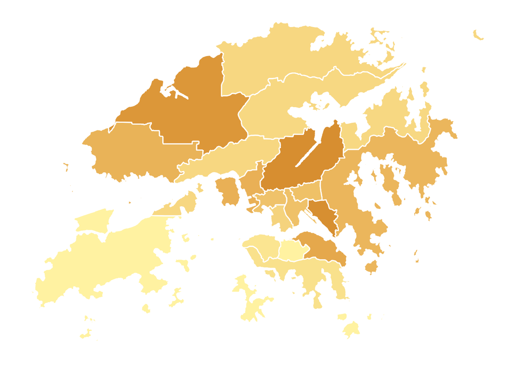

```r
# Here is the code to create a 2D map in Hongkong.
# Map
map_bg = ggplot(map_data, aes(long, lat, group=group, fill = Population)) +
  geom_polygon() + # Shape
  scale_fill_gradient(limits=range(map_data$Population),
                      low="#FFF3B0", high="#E09F3E") + # Population Density Color
  layer(geom="path", stat="identity", position="identity",
       mapping=aes(x=long, y=lat, group=group,
                   color=I('#FFFFFF'))) # Boarder Color

map_bg = map_bg + theme(legend.position = "none",
                        axis.line=element_blank(),
                        axis.text.x=element_blank(), axis.title.x=element_blank(),
                        axis.text.y=element_blank(), axis.title.y=element_blank(),
                        axis.ticks=element_blank(),
                        panel.background = element_blank()) # Clean Everything
map_bg
```

```r
# Save as PNG
xlim = ggplot_build(map_bg)$layout$panel_scales_x[[1]]$range$range
ylim = ggplot_build(map_bg)$layout$panel_scales_y[[1]]$range$range
ggsave('map_bg.png', width = diff(xlim)*40, height = diff(ylim)*40, units = "cm")
```

```r
# Real Estate Dataset
estate_df = readr::read_csv('https://raw.githubusercontent.com/cydalytics/HK_Properties_Price_Distribution/master/real_estate_master_df.csv')
estate_df$apr_price = as.numeric(gsub('[^0-9]', '', estate_df$Price_Per_SqFeet_Apr2020))
estate_df$mar_price = as.numeric(gsub('[^0-9]', '', estate_df$Price_Per_SqFeet_Mar2020))
```

```r
# Read Background Image
hk_map_bg = readPNG('map_bg.png')
```

Here is the 2D map that we need to turn into 3D.

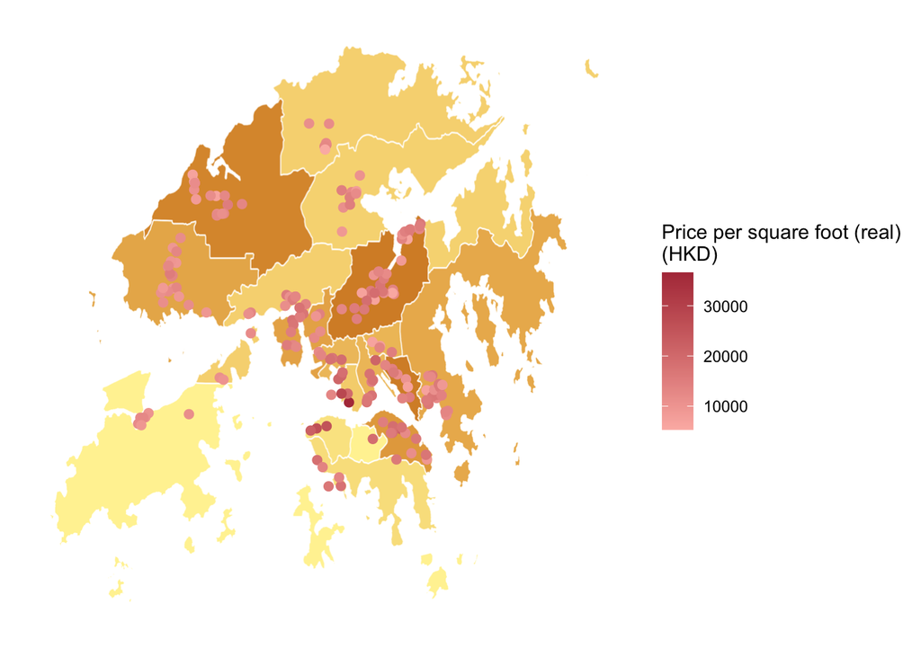

```r
# 2D Plot
library(ggplot2)
library(grid)
estate_price = ggplot(estate_df) +
  annotation_custom(rasterGrob(hk_map_bg, width=unit(1,"npc"), height=unit(1,"npc")),
                    -Inf, Inf, -Inf, Inf) + # Background
  xlim(xlim[1],xlim[2]) + # x-axis Mapping
  ylim(ylim[1],ylim[2]) + # y-axis Mapping
  geom_point(aes(x=Longitude, y=Latitude, color=apr_price), size=2) + # Points
  scale_colour_gradient(name = 'Price per square foot (real)\n(HKD)',
                        limits=range(estate_df$apr_price),
                        low="#FCB9B2", high="#B23A48") + # Price Density Color
  theme(axis.line=element_blank(),
        axis.text.x=element_blank(), axis.title.x=element_blank(),
        axis.text.y=element_blank(), axis.title.y=element_blank(),
        axis.ticks=element_blank(),
        panel.background = element_blank()) # Clean Everything
estate_price
```

```r
ggsave('estate_price.png', width = diff(xlim)*40, height = diff(ylim)*40, units = "cm")
```

Creating a 3D plot here would be a great idea to see distinguish each point. Especially if it is a 3D interactive plot. To do so, we might want to use a code such as the one bellow

library(rgl) par3d(windowRect = c(0, 0, diff(xlim) * 2500, diff(ylim) * 2500))